# Discrete Probability Calculations

Xinyu Gao

September 24, 2021

# 1 Introduction

The purpose of this assignment is to answer the questions related to the world series using the rules of probability and discrete probability functions.

## 1.1 Background

The world series is a best-of-7-match-up (can be best-of-odd_num-match-up) between the champions of the American and National Leagues of Major Baseball. The definition of winning a game is that one team has won (7+1)/2 wins. In this problem, Braves and Yankees are teams competing in the World Series and the probability that the Braves win is P(B) and the probability that the Yankees win is P(Y)=1−P(B). Thus it is about binomial random variable. To be more specific, negative binomial random variable. Two probability functions are used in this assignment: “pnbinom” and “dnbinom”. dnbinom(x,y,p) means that given the probability p, find the the probability that when B event occurs Y times, A time appears X times. pnbinom(x,y,p) means that given the probability p,find the the probability that when B event occurs Y times, A time appears less than or equal to X times.

# 2 Methods

```r
library(tidyverse)
```

```r
library(ggplot2)
```

## 2.1 Question1

Braves wins, in other words it wins four games in the world series. When Braves wins the fourth game, the number of games Yankees can win is 0, 1, 2, 3 (<=3). Thus, this problem can be solved by using “pnbinom” function

```r
pnbinom(3,4,0.55)
```

```
## [1] 0.6082878
```

The probability that the Braves win the World Series given that P(B)=0.55 is 0.6082878

## 2.2 Question2

Braves wins, in other words it wins four games in the world series. When Braves wins the fourth game, the number of games Yankees can win is 0, 1, 2, 3 (<=3). Thus, the P(Braves Win World Series) = pnbinom(3,4,P(B)). In this question, we need to find the relationship between P(Braves Win World Series) and P(B). In this question, I set the probability range of P(B) as 0.5-1.0, increasing in 0.01 intervals. Then calculate the corresponding pnbinom value.

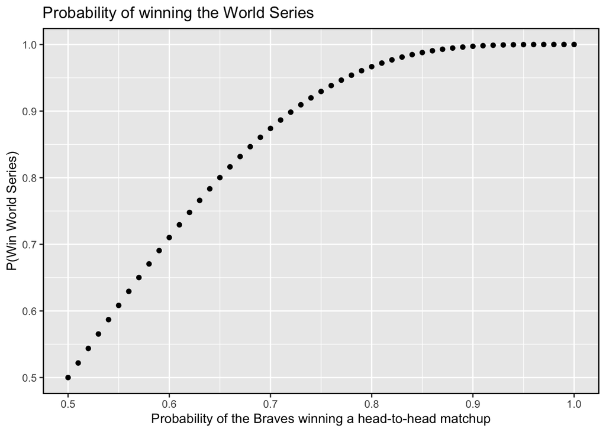

```r
# define the winning probability of Braves
prob_braves_2 <- seq(0.5,1.0,by = 0.01)
# define a vector to store the corresponding pnbinom values.
prob_win_2 <- rep(NA,length(prob_braves_2))
# use for loop to calculate the pnbinom values
for (i in 1:length(prob_braves_2)){
  prob_win_2[i] = pnbinom(3,4,prob_braves_2[i])
}
# construct a dataframe using winning probability of the Braves vector and the corresponding pnbinom vector
data.frame(prob_braves_2,prob_win_2) %>%
  # use ggplot to draw the graphic
  ggplot(aes(x=prob_braves_2,y=prob_win_2)) +
  geom_point() +
  # define the labels
  labs(
    x = "Probability of the Braves winning a head-to-head matchup",
    y = "P(Win World Series)",
    title = "Probability of winning the World Series"
  ) +
  # add the border
  theme(
    panel.border = element_rect(colour = "black", fill=NA, size=1)
  )
```

The X-axis is the probability of the Braves winning a head-to-head matchup and the Y-axis is the probability of the Braves win the world series. With the increase of P(B), P(Win World Series) increases from 0.5 fast and then slowly increases to 1.0.

## 2.3 Question3

Suppose the world series is best-of-x-match-up. Braves wins, in other words it wins (x+1)/2 games in the world series. When Braves wins the (x+1)/2 game, the number of games Yankees can win is 0, 1, 2,…,(x+1)/2-1 (<=(x+1)/2-1). Thus, the P(Braves Win World Series) = pnbinom((x+1)/2-1,(x+1)/2,0.55). In this question, we need to find the x that can make P(Braves Win World Series) >= 0.8

```r
#from the question2, we find that best-of-7-match-up can not get the probability exceeds 0.8. Thus, start from it can be faster to find the target series length
prob_win_3 <- pnbinom(3,4,0.55)
i <- 7
# loop until the P(Braves Win World Series) >= 0.8
while (prob_win_3 < 0.8)
{
  # update the series length by 2 because it must be an odd number
  i <- i + 2
  markline <- (i+1)/2
  # update the P(Braves Win World Series)
  prob_win_3 = pnbinom(markline-1,markline,0.55)
}
i
```

```
## [1] 71
```

The shortest series length so that P(Braves win World Series|PB =.55) ≥ 0.8 is 71.

## 2.4 Question4

Suppose the world series is best-of-x-match-up. Braves wins, in other words it wins (x+1)/2 games in the world series. When Braves wins the (x+1)/2 game, the number of games Yankees can win is 0, 1, 2,…,(x+1)/2-1 (<=(x+1)/2-1). Thus, the P(Braves Win World Series) = pnbinom((x+1)/2-1,(x+1)/2,P(B)). In this question, we need to find, for different P(B), the corresponding x that can make P(Braves Win World Series) >= 0.8

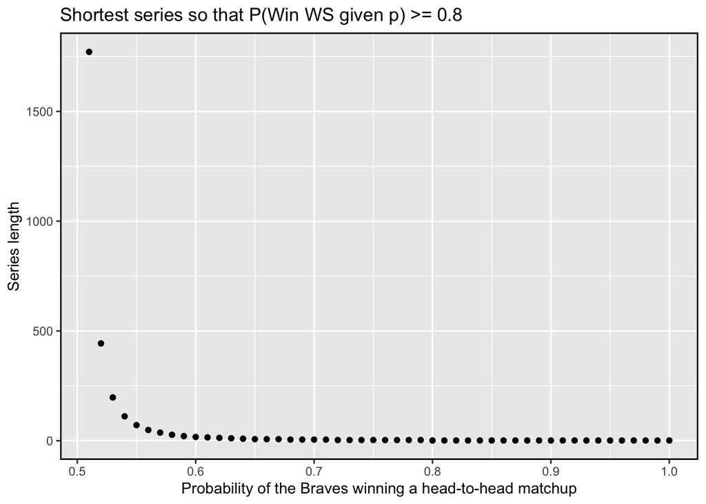

```r
# define the winning probability of Braves. The probability can not be 0.5 otherwise, it is impossible for P(Braves Win World Series) >= 0.8
prob_braves_4 <- seq(0.51,1.0,by = 0.01)
# define a vector to store the corresponding series length
series_len <- rep(NA,length(prob_braves_4))
# use for loop to try all probability values
for (i in 1:length(prob_braves_4))
{
  # for each new P(B), start from series length as 1
  series <- 1
  prob_win_4 <- pnbinom(0,1,prob_braves_4[i])
  # loop until the P(Braves Win World Series) >= 0.8
  while(prob_win_4 < 0.8)
  {
    # update the series length by 2
    series <- series + 2
    markline <- (series+1)/2
    # update the P(Braves Win World Series)
    prob_win_4 <- pnbinom(markline-1,markline,prob_braves_4[i])
  }
  # store the series length
  series_len[i] <- series
}

#construct a dataframe using winning probability of the Braves vector and the corresponding series length vector
data.frame(prob_braves_4,series_len) %>%
  # use ggplot to draw the graphic
  ggplot(aes(x=prob_braves_4,y=series_len)) +
  geom_point() +
  # define labels
  labs(
    x = "Probability of the Braves winning a head-to-head matchup",
    y = "Series length",
    title = "Shortest series so that P(Win WS given p) >= 0.8"
  )+
  # draw the border
   theme(
    panel.border = element_rect(colour = "black", fill=NA, size=1)
  )
```

## 2.5 Question5

Use Bayes Rule to extend the formula.
$$P(P(B)=0.55|Braves win World Series in 7 games) =$$
$$\frac{P(Braves win World Series in 7 games|P(B)=0.55) * P(P(B)=0.55)}{P(Braves win World Series in 7 games|P(B)=0.55) * P(P(B)=0.55)+P(Braves win World Series in 7 games|P(B)=0.45) * P(P(B)=0.45)}$$
P(Braves win World Series in 7 games|P(B)=0.55) means given P(B)=0.55, when Braves wins the fourth game, the number of games Yankees wins is 3 because it takes all 7 games to decide the winner
$$P(Braves win World Series in 7 games|P(B)=0.55) = dnbinom(3,4,0.55)$$
The assumption is that either P(B)=0.55 or P(B)=0.45
$$P(P(B)=0.55) = 0.5$$
P(Braves win World Series in 7 games|P(B)=0.45) means given P(B)=0.45, when Braves wins the fourth game, the number of games Yankees wins is 3 because it takes all 7 games to decide the winner
$$P(Braves win World Series in 7 games|P(B)=0.45) = dnbinom(3,4,0.45)$$
The assumption is that either P(B)=0.55 or P(B)=0.45
$$P(P(B)=0.45) = 0.5$$
$$P(P(B)=0.55|Braves win World Series in 7 games) = \frac{dnbinom(3,4,0.55)* 0.5}{dnbinom(3,4,0.55)* 0.5+dnbinom(3,4,0.45)* 0.5}$$

```r
# question 5
result <- dnbinom(3,4,0.55)*0.5/(dnbinom(3,4,0.55)* 0.5+dnbinom(3,4,0.45)* 0.5)
result
```

```
## [1] 0.55
```

Under the assumption that either PB=0.55 or PB=0.45, P(PB=0.55|Braves win World Series in 7 games) is 0.55.